# A Volatility Analysis of a Four-Cryptocurrency Portfolio

Mateusz Kowalski & Aleksandra Ciesińska

2024-07-04

We will be using the following libraries:

```r
library(dplyr)
library(xts)
library(fBasics)
library(tseries)
library(car)
library(FinTS)
library(fGarch)
library(rugarch)
library(ggplot2)
library(tidyr)
library(scales)
```

## **1. Data**

We will be analyzing a portfolio that consists of **4 cryptocurrencies: Avalanche, Cardano, Komodo and Monero**. Each day, the percentage allocation of each cryptocurrency in the portfolio is determined by its market capitalization. The plot below illustrates the daily allocation of each cryptocurrency within the portfolio (please note: Komodo’s allocation is approx. 0.1%).

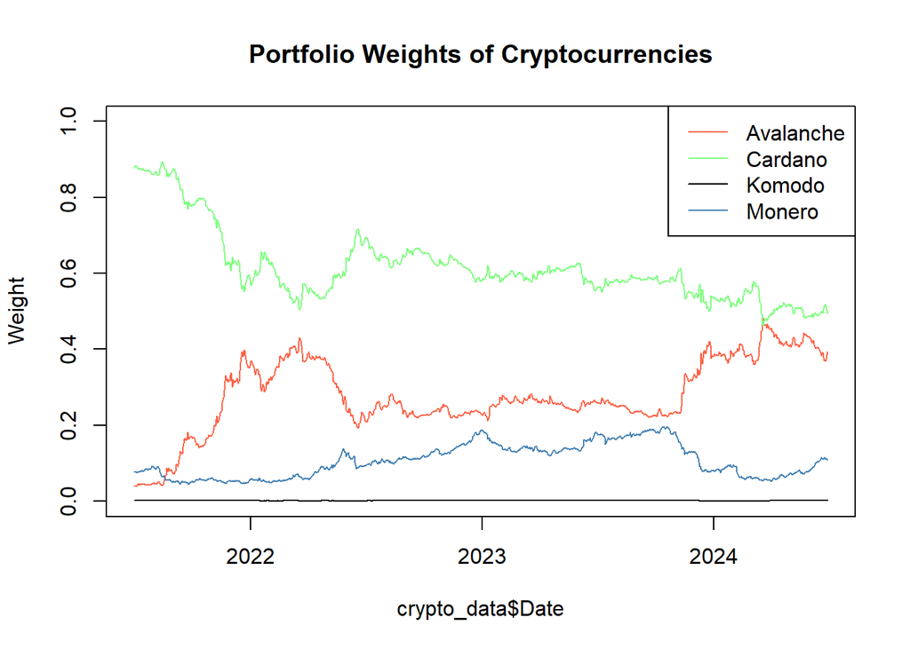

```
##       Min.    1st Qu.     Median       Mean    3rd Qu.       Max.
## -0.2525899 -0.0206787  0.0011353 -0.0007867  0.0204785  0.1559860
```

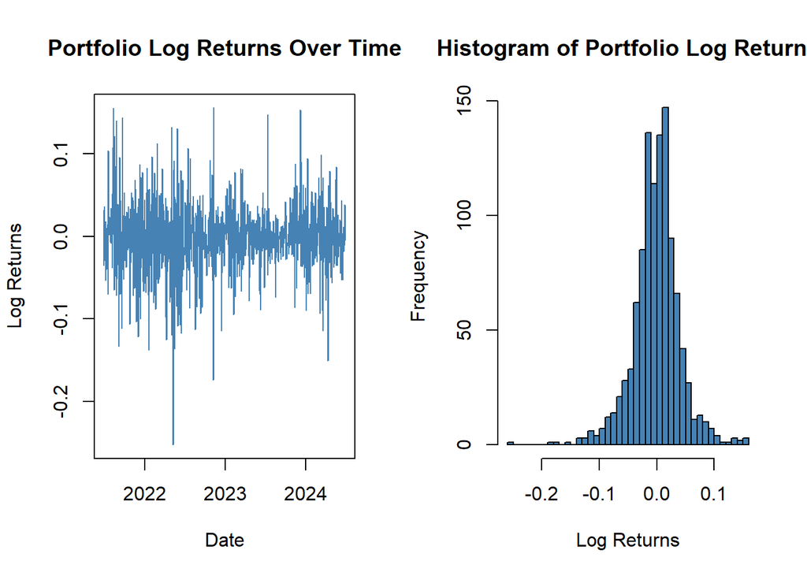

## **2. GARCH models**

In this section we will be considering **5 chosen types of GARCH models: GARCH, EGARCH, GARCH-t, TGARCH and GARCH-In-Mean**. If the model turns out successful, there are going to be additional plots presented and only 1 final model shown. Otherwise, we will present the process of finding the optimal model, indicating signs of misspecification within these models.

### 2.1. GARCH(1,1)

```
##
## *---------------------------------*
## *          GARCH Model Fit        *
## *---------------------------------*
##
## Conditional Variance Dynamics
## -----------------------------------
## GARCH Model  : sGARCH(1,1)
## Mean Model   : ARFIMA(0,0,0)
## Distribution : norm
##
## Optimal Parameters
## ------------------------------------
##         Estimate  Std. Error  t value Pr(>|t|)
## omega   0.000131    0.000035   3.7184 0.000201
## alpha1  0.168103    0.033779   4.9766 0.000001
## beta1   0.764141    0.041760  18.2982 0.000000
##
## Robust Standard Errors:
##         Estimate  Std. Error  t value Pr(>|t|)
## omega   0.000131    0.000059   2.2213 0.026328
## alpha1  0.168103    0.048569   3.4611 0.000538
## beta1   0.764141    0.059514  12.8396 0.000000
##
## LogLikelihood : 2014.659
##
## Information Criteria
## ------------------------------------
##
## Akaike       -3.6776
## Bayes        -3.6639
## Shibata      -3.6776
## Hannan-Quinn -3.6724
##
## Weighted Ljung-Box Test on Standardized Residuals
## ------------------------------------
##                         statistic p-value
## Lag[1]                    0.01262  0.9105
## Lag[2*(p+q)+(p+q)-1][2]   0.05876  0.9496
## Lag[4*(p+q)+(p+q)-1][5]   3.30202  0.3547
```

[output cut: 34 more lines]

```
## Negative Sign Bias  0.1548 0.8770
## Positive Sign Bias  1.4243 0.1546
## Joint Effect        4.1789 0.2428
##
##
## Adjusted Pearson Goodness-of-Fit Test:
## ------------------------------------
##   group statistic p-value(g-1)
## 1    20     78.94    2.827e-09
## 2    30     85.05    2.063e-07
## 3    40     96.64    8.509e-07
## 4    50    109.93    1.424e-06
##
##
## Elapsed time : 0.151243
```

```
##
## please wait...calculating quantiles...
```

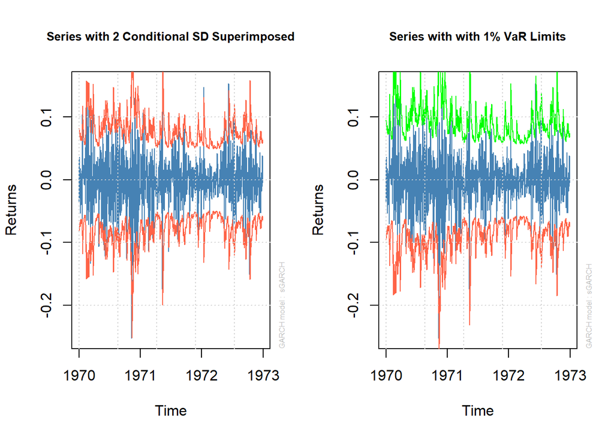

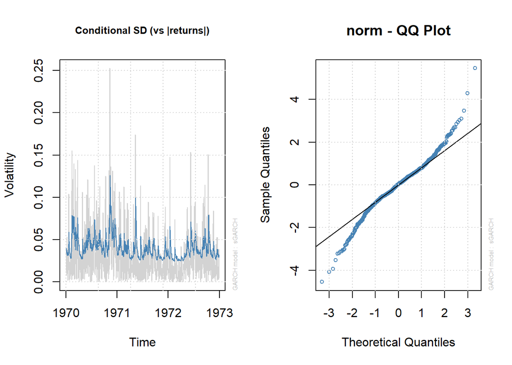

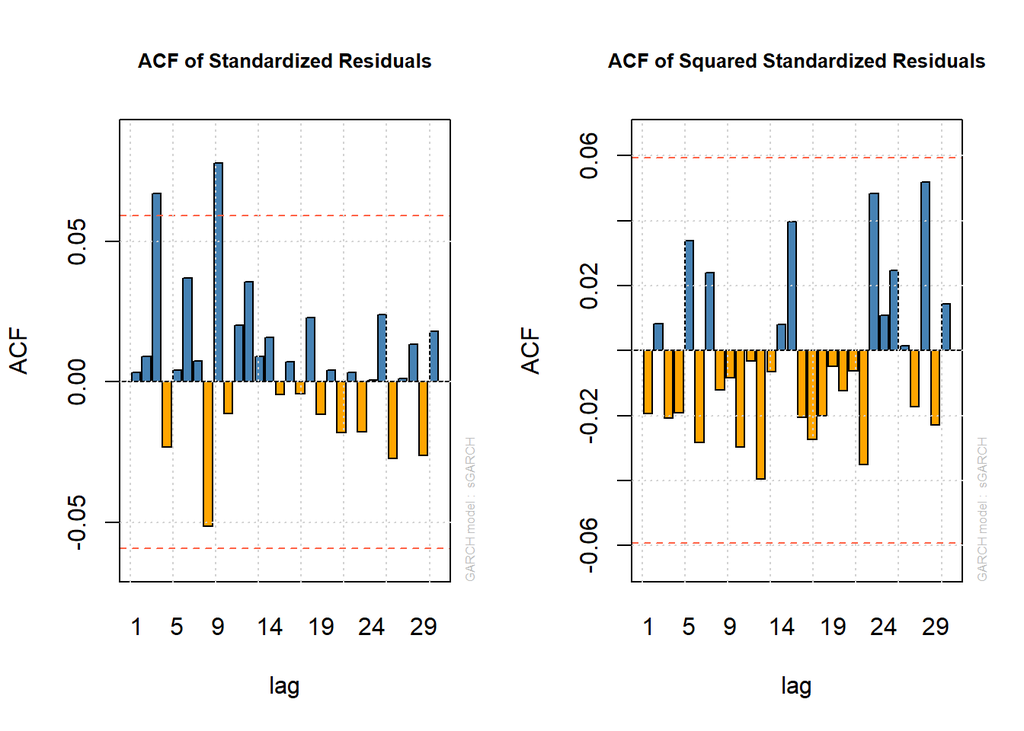

#### Tests & Plots

- (+/-) **Autocorrelation of st. residuals:** no autocorrelation up to the last lag taken into account
  - *but! ACF plot: 3rd and 9th lags are problematic*
- (+) **Autocorrelation of sq. st. residuals:** no autocorrelation up to the last lag taken into account
  - *ACF: results are consistent*
- (+) **Nyblom Stability Test:** not rejecting H0 postulating parameters’ stability
- (+) **LM Arch Test:** no ARCH effects up to the last lag taken into account
- (+) **Sign Test:** not rejecting H0 postulating no presence of leverage effects in the standardized residuals
- (-) **Pearson Goodness-of-Fit:** rejecting H0 postulating that the empirical distribution is equal to the assumed distribution (irrespective of the choice of bins)

#### Leverage Effects

Leverage effects are understood as the impact of positive and negative return shocks on volatility not predicted by the model under consideration (their presence indicates misspecification).

More complicated versions of this GARCH type model produced worse results. Thus, there is no point in making the model too complex if the simpler alternative provides better fit.

### 2.2. GARCH-t(1,1)

```
##
## *---------------------------------*
## *          GARCH Model Fit        *
## *---------------------------------*
##
## Conditional Variance Dynamics
## -----------------------------------
## GARCH Model  : sGARCH(1,1)
## Mean Model   : ARFIMA(0,0,0)
## Distribution : std
##
## Optimal Parameters
## ------------------------------------
##         Estimate  Std. Error  t value Pr(>|t|)
## omega    0.00008    0.000033   2.3918 0.016767
## alpha1   0.17848    0.045236   3.9455 0.000080
## beta1    0.79929    0.045819  17.4444 0.000000
## shape    4.51930    0.626864   7.2094 0.000000
##
## Robust Standard Errors:
##         Estimate  Std. Error  t value Pr(>|t|)
## omega    0.00008    0.000042   1.9212 0.054712
## alpha1   0.17848    0.048602   3.6722 0.000240
## beta1    0.79929    0.055004  14.5316 0.000000
## shape    4.51930    0.566515   7.9774 0.000000
##
## LogLikelihood : 2062.36
##
## Information Criteria
## ------------------------------------
##
## Akaike       -3.7630
## Bayes        -3.7447
## Shibata      -3.7630
## Hannan-Quinn -3.7561
##
## Weighted Ljung-Box Test on Standardized Residuals
## ------------------------------------
##                         statistic p-value
## Lag[1]                    0.04558  0.8309
```

[output cut: 37 more lines]

```
## Negative Sign Bias  0.1630 0.8705
## Positive Sign Bias  1.5162 0.1298
## Joint Effect        4.5255 0.2100
##
##
## Adjusted Pearson Goodness-of-Fit Test:
## ------------------------------------
##   group statistic p-value(g-1)
## 1    20     28.12      0.08113
## 2    30     36.84      0.15034
## 3    40     49.62      0.11862
## 4    50     58.65      0.16263
##
##
## Elapsed time : 0.2038231
```

```
##
## please wait...calculating quantiles...
```

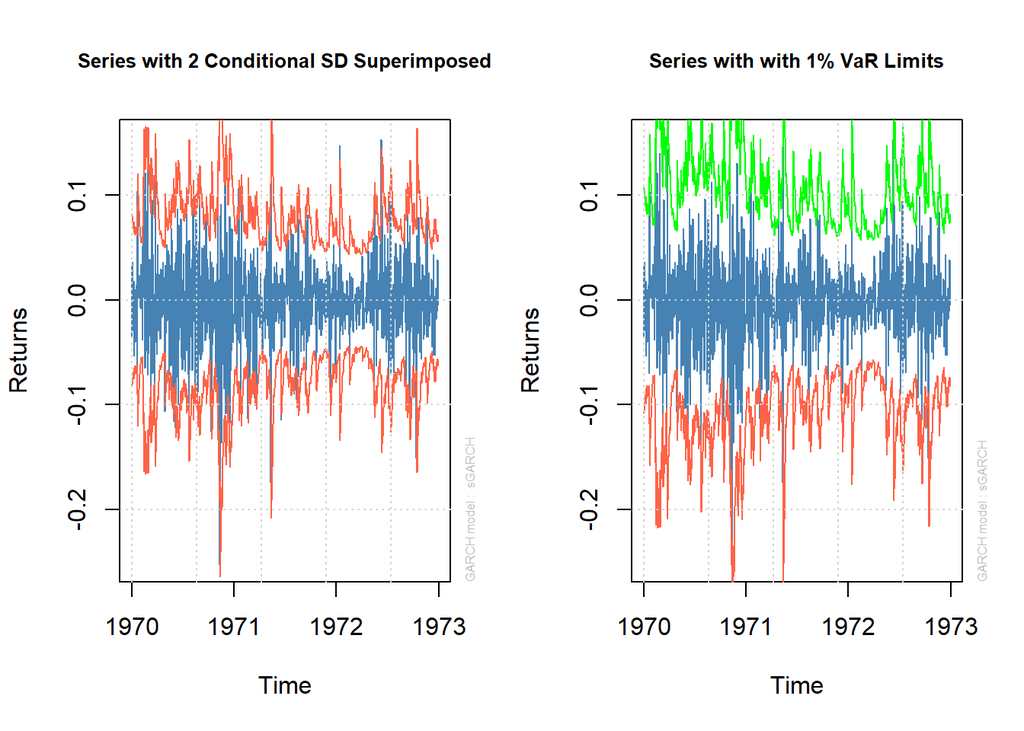

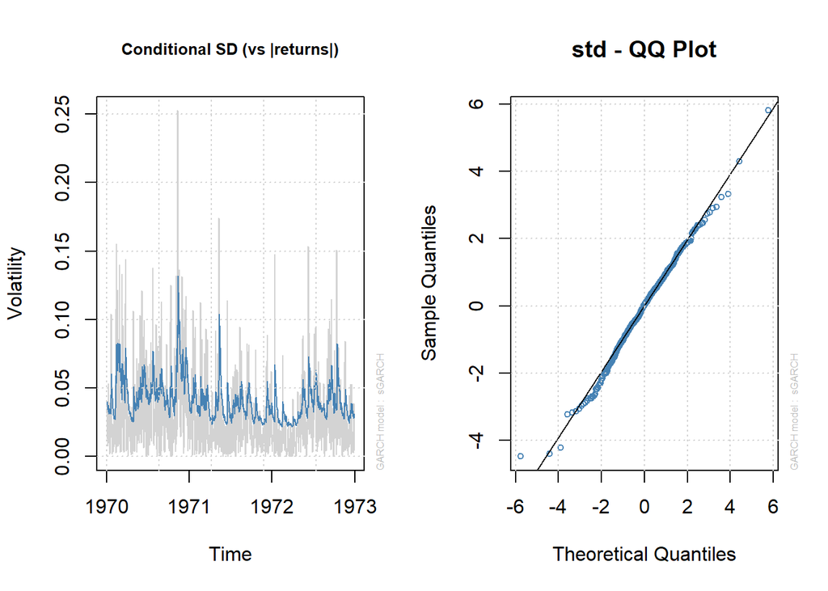

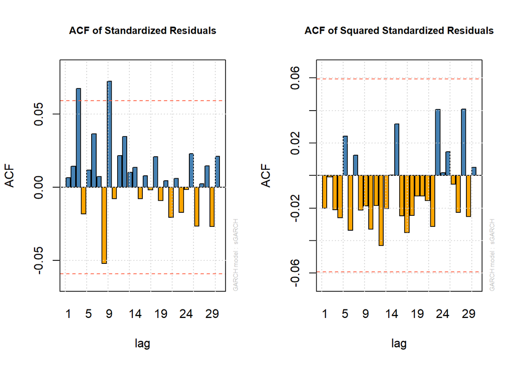

#### Parameters

- **omega (cons.):** insignificant in the robust variant
- **alpha1, beta1 > 0:** variance greater than 0
- **alpha1 + beta1 < 1:** GARCH(1,1) process is stationary

#### Tests & Plots

Also, **the QQPlot looks way better** - theoretical quantiles fit empirical ones better than while considering GARCH(1,1).

To sum up, GARCH-t(1,1) seems to be better than GARCH(1,1). From now on, we will always check variants with t-distributed residuals.

### 2.3. EGARCH(1,1)

```
##
## *---------------------------------*
## *          GARCH Model Fit        *
## *---------------------------------*
##
## Conditional Variance Dynamics
## -----------------------------------
## GARCH Model  : eGARCH(1,1)
## Mean Model   : ARFIMA(0,0,0)
## Distribution : std
##
## Optimal Parameters
## ------------------------------------
##         Estimate  Std. Error  t value Pr(>|t|)
## omega   -0.33897    0.133239 -2.54408 0.010956
## alpha1   0.01236    0.028572  0.43258 0.665317
## beta1    0.94802    0.020386 46.50456 0.000000
## gamma1   0.29957    0.062693  4.77842 0.000002
## shape    4.60801    0.646964  7.12251 0.000000
##
## Robust Standard Errors:
##         Estimate  Std. Error  t value Pr(>|t|)
## omega   -0.33897    0.148015 -2.29012 0.022015
## alpha1   0.01236    0.029344  0.42121 0.673598
## beta1    0.94802    0.022645 41.86429 0.000000
## gamma1   0.29957    0.071151  4.21044 0.000025
## shape    4.60801    0.583926  7.89142 0.000000
##
## LogLikelihood : 2067.08
##
## Information Criteria
## ------------------------------------
##
## Akaike       -3.7698
## Bayes        -3.7470
## Shibata      -3.7698
## Hannan-Quinn -3.7612
##
## Weighted Ljung-Box Test on Standardized Residuals
## ------------------------------------
```

[output cut: 40 more lines]

```
## Negative Sign Bias  0.3846 0.7006
## Positive Sign Bias  1.4740 0.1408
## Joint Effect        4.9123 0.1783
##
##
## Adjusted Pearson Goodness-of-Fit Test:
## ------------------------------------
##   group statistic p-value(g-1)
## 1    20     28.45      0.07515
## 2    30     37.06      0.14469
## 3    40     43.11      0.29977
## 4    50     49.05      0.47100
##
##
## Elapsed time : 0.2431729
```

```
##
## please wait...calculating quantiles...
```

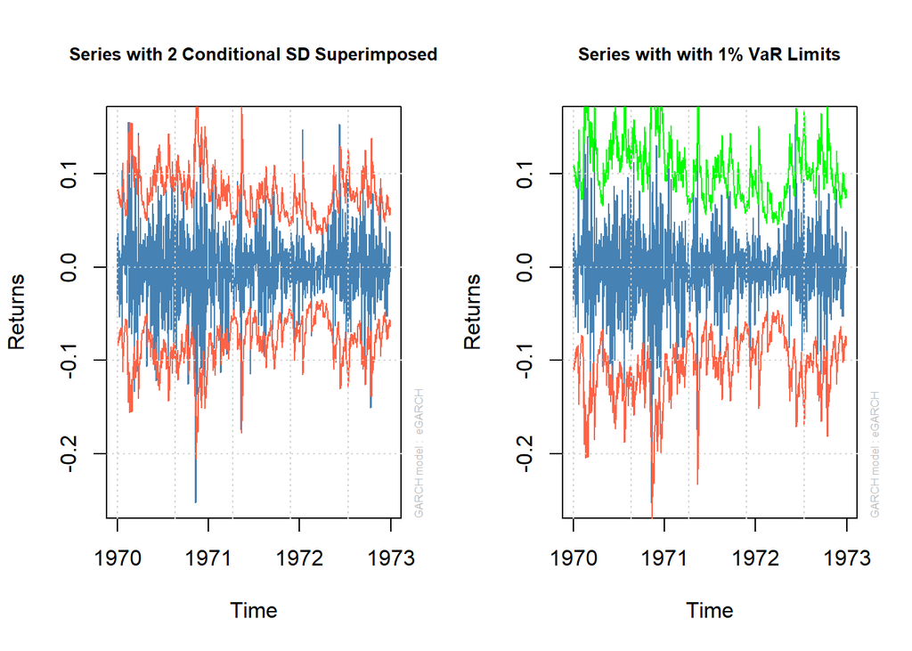

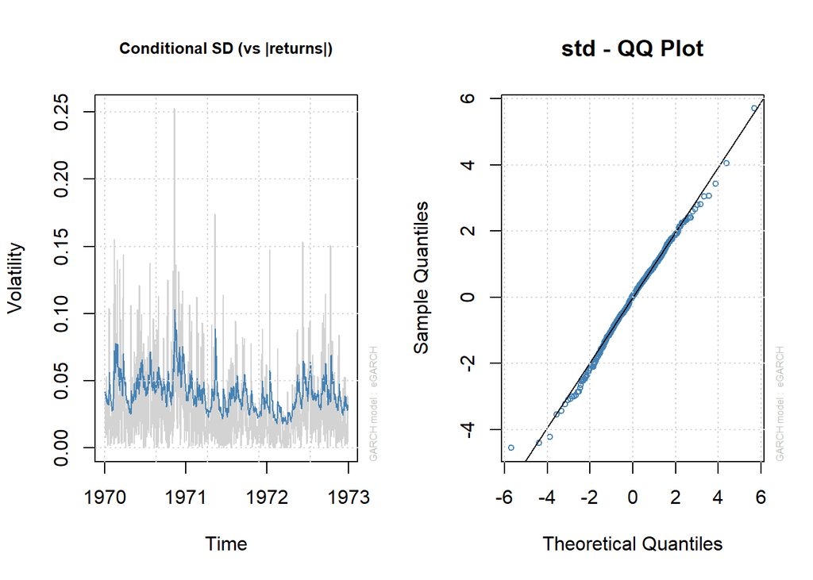

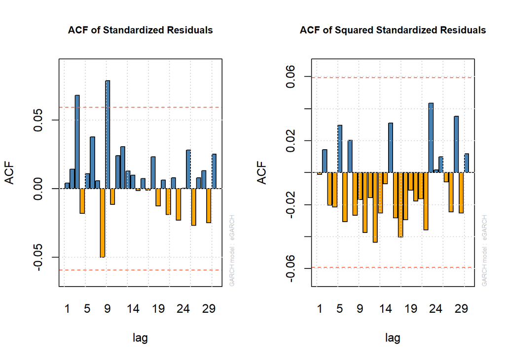

#### Parameters

- **alpha1:** insignificant
- **Variance:** is always greater than 0 in this GARCH type
- **gamma > 0:** variance reaction to shocks is symmetrical (EGARCH allows negative gamma meaning that the reaction is not symmetrical)

#### Tests & Plots

More complicated versions of this GARCH model type produced worse results.

### 2.4. Threshold GARCH

##### Version I: TGARCH(1, 1)

```
##
## *---------------------------------*
## *          GARCH Model Fit        *
## *---------------------------------*
##
## Conditional Variance Dynamics
## -----------------------------------
## GARCH Model  : fGARCH(1,1)
## fGARCH Sub-Model : TGARCH
## Mean Model   : ARFIMA(0,0,0)
## Distribution : std
##
## Optimal Parameters
## ------------------------------------
##         Estimate  Std. Error  t value Pr(>|t|)
## omega   0.001630    0.000827  1.97222 0.048584
## alpha1  0.156684    0.039685  3.94821 0.000079
## beta1   0.846300    0.044727 18.92159 0.000000
## eta11  -0.066003    0.109022 -0.60542 0.544903
## shape   4.631263    0.645590  7.17369 0.000000
##
## Robust Standard Errors:
##         Estimate  Std. Error  t value Pr(>|t|)
## omega   0.001630    0.001105  1.47590 0.139971
## alpha1  0.156684    0.050909  3.07775 0.002086
## beta1   0.846300    0.061119 13.84677 0.000000
## eta11  -0.066003    0.125133 -0.52746 0.597871
## shape   4.631263    0.583568  7.93611 0.000000
##
## LogLikelihood : 2067.062
##
## Information Criteria
## ------------------------------------
##
## Akaike       -3.7698
## Bayes        -3.7469
## Shibata      -3.7698
## Hannan-Quinn -3.7611
##
## Weighted Ljung-Box Test on Standardized Residuals
```

[output cut: 41 more lines]

```
## Negative Sign Bias  0.5371 0.5913
## Positive Sign Bias  1.4815 0.1388
## Joint Effect        5.3174 0.1500
##
##
## Adjusted Pearson Goodness-of-Fit Test:
## ------------------------------------
##   group statistic p-value(g-1)
## 1    20     29.07      0.06487
## 2    30     34.76      0.21264
## 3    40     54.23      0.05332
## 4    50     59.38      0.14710
##
##
## Elapsed time : 0.3373291
```

The most important observation is that *eta11* is insignificant which makes this model tantamount to ordinary GARCH.

##### Version II: TGARCH(2, 1)

```
##
## *---------------------------------*
## *          GARCH Model Fit        *
## *---------------------------------*
##
## Conditional Variance Dynamics
## -----------------------------------
## GARCH Model  : fGARCH(2,1)
## fGARCH Sub-Model : TGARCH
## Mean Model   : ARFIMA(0,0,0)
## Distribution : std
##
## Optimal Parameters
## ------------------------------------
##         Estimate  Std. Error   t value Pr(>|t|)
## omega   0.001632    0.000826  1.975852 0.048172
## alpha1  0.156577    0.039609  3.953025 0.000077
## alpha2  0.000000    0.000018  0.000027 0.999978
## beta1   0.846266    0.044689 18.936649 0.000000
## eta11  -0.066999    0.109084 -0.614196 0.539086
## eta12   0.164905    0.373495  0.441518 0.658838
## shape   4.643109    0.646818  7.178388 0.000000
##
## Robust Standard Errors:
##         Estimate  Std. Error   t value Pr(>|t|)
## omega   0.001632    0.001105  1.476890 0.139705
## alpha1  0.156577    0.050846  3.079439 0.002074
## alpha2  0.000000    0.000000  0.040246 0.967897
## beta1   0.846266    0.061125 13.844912 0.000000
## eta11  -0.066999    0.125466 -0.534001 0.593341
## eta12   0.164905    0.502722  0.328025 0.742893
## shape   4.643109    0.585341  7.932320 0.000000
##
## LogLikelihood : 2067.01
##
## Information Criteria
## ------------------------------------
##
## Akaike       -3.7660
## Bayes        -3.7340
```

[output cut: 47 more lines]

```
## Negative Sign Bias  0.5398 0.5894
## Positive Sign Bias  1.4825 0.1385
## Joint Effect        5.3453 0.1482
##
##
## Adjusted Pearson Goodness-of-Fit Test:
## ------------------------------------
##   group statistic p-value(g-1)
## 1    20     29.44      0.05942
## 2    30     34.87      0.20896
## 3    40     55.03      0.04587
## 4    50     58.47      0.16669
##
##
## Elapsed time : 0.916533
```

It is important to note that *alpha2* is insignificant, so using TGARCH(2,1), in other words adding *alpha2* to the previous version of the model, was pointless.

##### Version III: TGARCH(1, 2)

```
##
## *---------------------------------*
## *          GARCH Model Fit        *
## *---------------------------------*
##
## Conditional Variance Dynamics
## -----------------------------------
## GARCH Model  : fGARCH(1,2)
## fGARCH Sub-Model : TGARCH
## Mean Model   : ARFIMA(0,0,0)
## Distribution : std
##
## Optimal Parameters
## ------------------------------------
##         Estimate  Std. Error  t value Pr(>|t|)
## omega   0.001638    0.000832  1.96874 0.048983
## alpha1  0.160365    0.043875  3.65502 0.000257
## beta1   0.797406    0.243369  3.27653 0.001051
## beta2   0.045967    0.226386  0.20305 0.839097
## eta11  -0.067596    0.109361 -0.61811 0.536506
## shape   4.638206    0.645601  7.18432 0.000000
##
## Robust Standard Errors:
##         Estimate  Std. Error  t value Pr(>|t|)
## omega   0.001638    0.001098  1.49271 0.135513
## alpha1  0.160365    0.047012  3.41114 0.000647
## beta1   0.797406    0.177597  4.48998 0.000007
## beta2   0.045967    0.186854  0.24601 0.805676
## eta11  -0.067596    0.126117 -0.53598 0.591972
## shape   4.638206    0.586842  7.90367 0.000000
##
## LogLikelihood : 2067.031
##
## Information Criteria
## ------------------------------------
##
## Akaike       -3.7679
## Bayes        -3.7405
## Shibata      -3.7679
## Hannan-Quinn -3.7575
```

[output cut: 44 more lines]

```
## Negative Sign Bias  0.5013 0.6163
## Positive Sign Bias  1.5196 0.1289
## Joint Effect        5.3144 0.1502
##
##
## Adjusted Pearson Goodness-of-Fit Test:
## ------------------------------------
##   group statistic p-value(g-1)
## 1    20     28.27      0.07842
## 2    30     35.74      0.18114
## 3    40     49.03      0.13024
## 4    50     54.54      0.27213
##
##
## Elapsed time : 0.455431
```

Now *beta2* is insigificant, so using TGARCH(1,2), i.e. adding *beta2*, turned out counterproductive.

In spite of seemingly promising test results for all tested versions, **TGARCH models do not seem to be a good option for this analysis** due to insignificant parameters. Each time the crucial parameter, either eta which is typical to TGARCH modelling or parameters vital to make the model a bit more complicated, is not significant.

We also tried to manipulate with the mean equation trying: ARFIMA(0,0,0), ARFIMA(1,0,0) and ARFIMA(0,0,1), however the results did not differ much. Thus, we are going to skip TGARCH models with different mean specifications.

### 2.5. GARCH-In-Mean

##### Version I

```
##
## *---------------------------------*
## *          GARCH Model Fit        *
## *---------------------------------*
##
## Conditional Variance Dynamics
## -----------------------------------
## GARCH Model  : sGARCH(1,1)
## Mean Model   : ARFIMA(0,0,0)
## Distribution : norm
##
## Optimal Parameters
## ------------------------------------
##         Estimate  Std. Error  t value Pr(>|t|)
## mu     -0.003325    0.004357 -0.76296 0.445486
## archm   0.072339    0.120330  0.60117 0.547727
## omega   0.000132    0.000036  3.69078 0.000224
## alpha1  0.170371    0.033989  5.01254 0.000001
## beta1   0.761675    0.042151 18.07013 0.000000
##
## Robust Standard Errors:
##         Estimate  Std. Error  t value Pr(>|t|)
## mu     -0.003325    0.004302 -0.77273 0.439682
## archm   0.072339    0.112830  0.64113 0.521437
## omega   0.000132    0.000060  2.18472 0.028909
## alpha1  0.170371    0.048489  3.51361 0.000442
## beta1   0.761675    0.059862 12.72393 0.000000
##
## LogLikelihood : 2015.112
##
## Information Criteria
## ------------------------------------
##
## Akaike       -3.6748
## Bayes        -3.6520
## Shibata      -3.6748
## Hannan-Quinn -3.6661
##
## Weighted Ljung-Box Test on Standardized Residuals
## ------------------------------------
```

[output cut: 40 more lines]

```
## Negative Sign Bias  0.1604 0.8726
## Positive Sign Bias  1.2678 0.2052
## Joint Effect        4.8460 0.1834
##
##
## Adjusted Pearson Goodness-of-Fit Test:
## ------------------------------------
##   group statistic p-value(g-1)
## 1    20     80.26    1.677e-09
## 2    30     89.16    4.895e-08
## 3    40     97.08    7.411e-07
## 4    50    100.42    2.106e-05
##
##
## Elapsed time : 0.3935249
```

The parameter *archm* is insignificant which makes the model ordinary GARCH, as in the Section 2.4.

##### Version II

```
##
## *---------------------------------*
## *          GARCH Model Fit        *
## *---------------------------------*
##
## Conditional Variance Dynamics
## -----------------------------------
## GARCH Model  : sGARCH(2,1)
## Mean Model   : ARFIMA(0,0,0)
## Distribution : std
##
## Optimal Parameters
## ------------------------------------
##         Estimate  Std. Error  t value Pr(>|t|)
## mu     -0.002909    0.003230 -0.90044 0.367886
## archm   0.075249    0.090244  0.83384 0.404371
## omega   0.000092    0.000043  2.12703 0.033418
## alpha1  0.169811    0.059688  2.84500 0.004441
## alpha2  0.029912    0.077961  0.38368 0.701216
## beta1   0.775046    0.065716 11.79378 0.000000
## shape   4.529187    0.634414  7.13917 0.000000
##
## Robust Standard Errors:
##         Estimate  Std. Error  t value Pr(>|t|)
## mu     -0.002909    0.002942 -0.98870 0.322808
## archm   0.075249    0.078378  0.96009 0.337012
## omega   0.000092    0.000057  1.61765 0.105738
## alpha1  0.169811    0.055188  3.07698 0.002091
## alpha2  0.029912    0.085873  0.34833 0.727592
## beta1   0.775046    0.084748  9.14528 0.000000
## shape   4.529187    0.582620  7.77382 0.000000
##
## LogLikelihood : 2062.796
##
## Information Criteria
## ------------------------------------
##
## Akaike       -3.7583
## Bayes        -3.7263
## Shibata      -3.7584
```

[output cut: 46 more lines]

```
## Negative Sign Bias  0.5212 0.6023
## Positive Sign Bias  1.1807 0.2380
## Joint Effect        5.4740 0.1402
##
##
## Adjusted Pearson Goodness-of-Fit Test:
## ------------------------------------
##   group statistic p-value(g-1)
## 1    20     35.84      0.01106
## 2    30     40.68      0.07342
## 3    40     55.18      0.04461
## 4    50     59.38      0.14710
##
##
## Elapsed time : 0.570493
```

Now most of the parameters are insignificant and the model is really bad.

##### Version III

```
##
## *---------------------------------*
## *          GARCH Model Fit        *
## *---------------------------------*
##
## Conditional Variance Dynamics
## -----------------------------------
## GARCH Model  : sGARCH(1,2)
## Mean Model   : ARFIMA(0,0,0)
## Distribution : std
##
## Optimal Parameters
## ------------------------------------
##         Estimate  Std. Error   t value Pr(>|t|)
## mu     -0.002765    0.003241 -0.853124 0.393590
## archm   0.071548    0.090455  0.790974 0.428959
## omega   0.000084    0.000036  2.348957 0.018826
## alpha1  0.185268    0.052675  3.517200 0.000436
## beta1   0.792156    0.254048  3.118132 0.001820
## beta2   0.000001    0.223230  0.000003 0.999997
## shape   4.508110    0.627300  7.186533 0.000000
##
## Robust Standard Errors:
##         Estimate  Std. Error   t value Pr(>|t|)
## mu     -0.002765    0.002965 -0.932634 0.351009
## archm   0.071548    0.078431  0.912238 0.361643
## omega   0.000084    0.000043  1.966920 0.049192
## alpha1  0.185268    0.045363  4.084117 0.000044
## beta1   0.792156    0.180683  4.384240 0.000012
## beta2   0.000001    0.174942  0.000004 0.999996
## shape   4.508110    0.568647  7.927782 0.000000
##
## LogLikelihood : 2062.724
##
## Information Criteria
## ------------------------------------
##
## Akaike       -3.7582
## Bayes        -3.7262
## Shibata      -3.7583
```

[output cut: 46 more lines]

```
## Negative Sign Bias  0.6136 0.5396
## Positive Sign Bias  1.2884 0.1979
## Joint Effect        5.4807 0.1398
##
##
## Adjusted Pearson Goodness-of-Fit Test:
## ------------------------------------
##   group statistic p-value(g-1)
## 1    20     32.22      0.02955
## 2    30     36.35      0.16366
## 3    40     54.23      0.05332
## 4    50     61.30      0.11166
##
##
## Elapsed time : 0.3855731
```

**GARCH-In-Mean models do not seem to be a good option for this analysis** due to insignificant parameters. Each time the crucial parameter archm is insignificant, which suggests that a typical GARCH model could be better.

Attempts to successfully extend either variance or mean equations turn out counterproductive - more complex models are even worse.

##### **Conclusions**

Important conclusion to be drawn is that assuming residuals to be t-distributed had a neutral or positive impact on the quality of the model (comparing it with a normal distribution). This is an expected outcome as **financial data are often leptokurtic - t or GED distributions are the common choice**.

## **3. Conditional variance in-sample forecast**

In this section we will use our best GARCH models for predicting the level of unconditional variance. After that we will present on the plot of the convergence of the conditional variance to the unconditional variance. The forecast is going to be calculated for 500 days ahead.

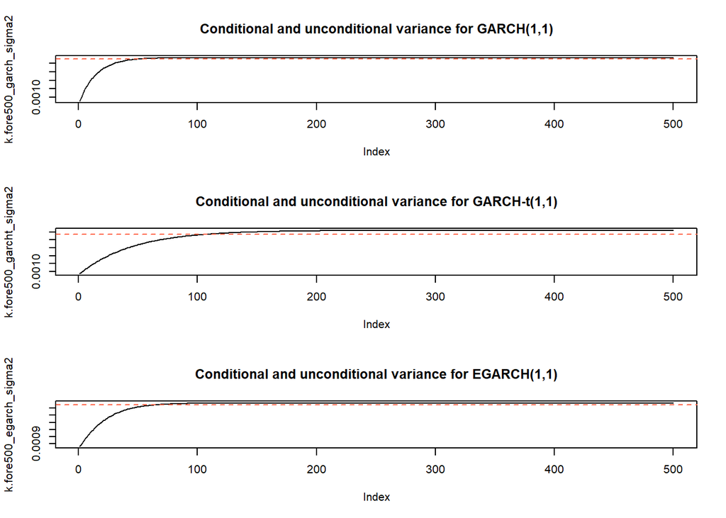

## **4. 99% Value-at-Risk out-of-sample forecast**

In this section we are going to calculate 99% Value-at-Risk the period from April to June 2024. The exceedance percentages are going to be computed at the end of this section, providing us with final conclusions for this analysis.

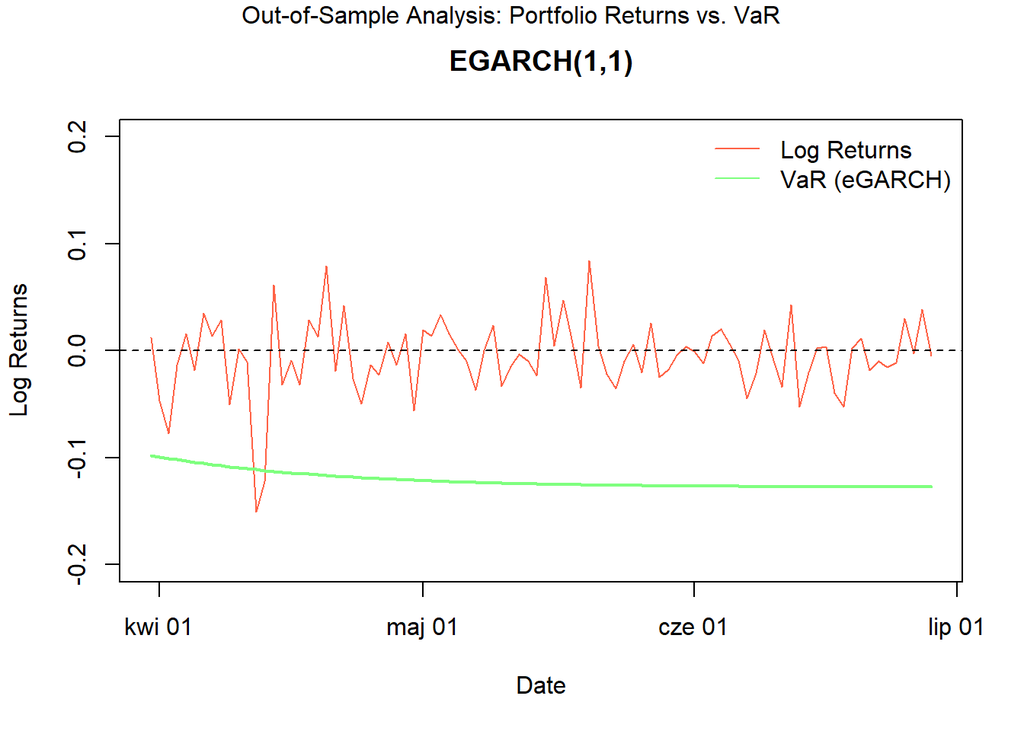

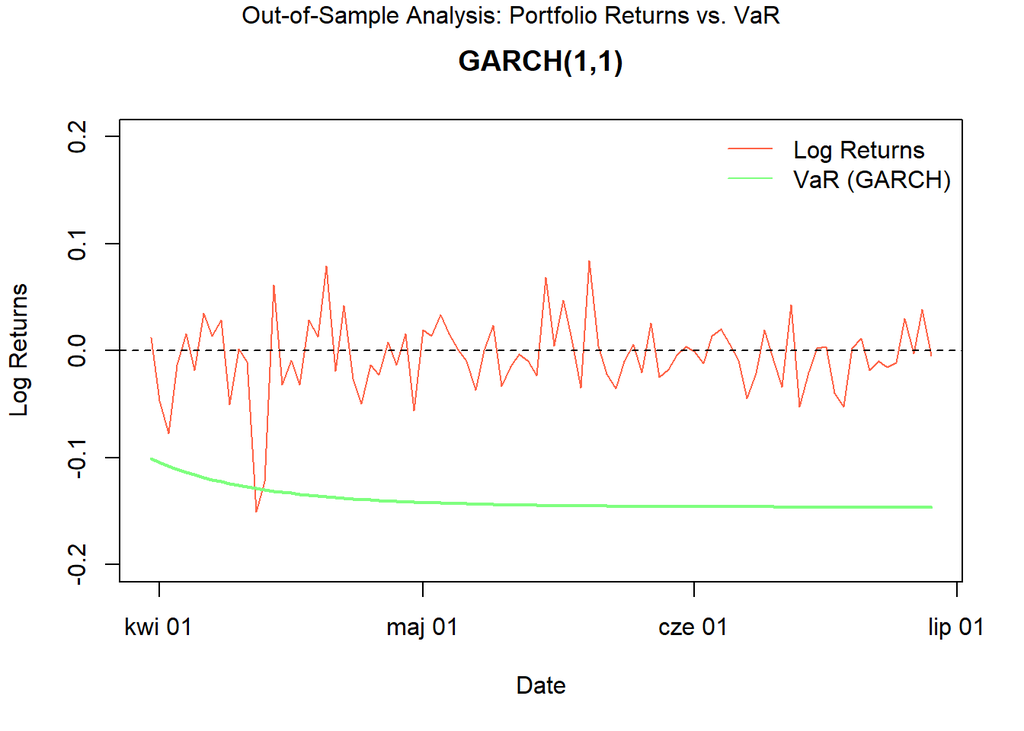

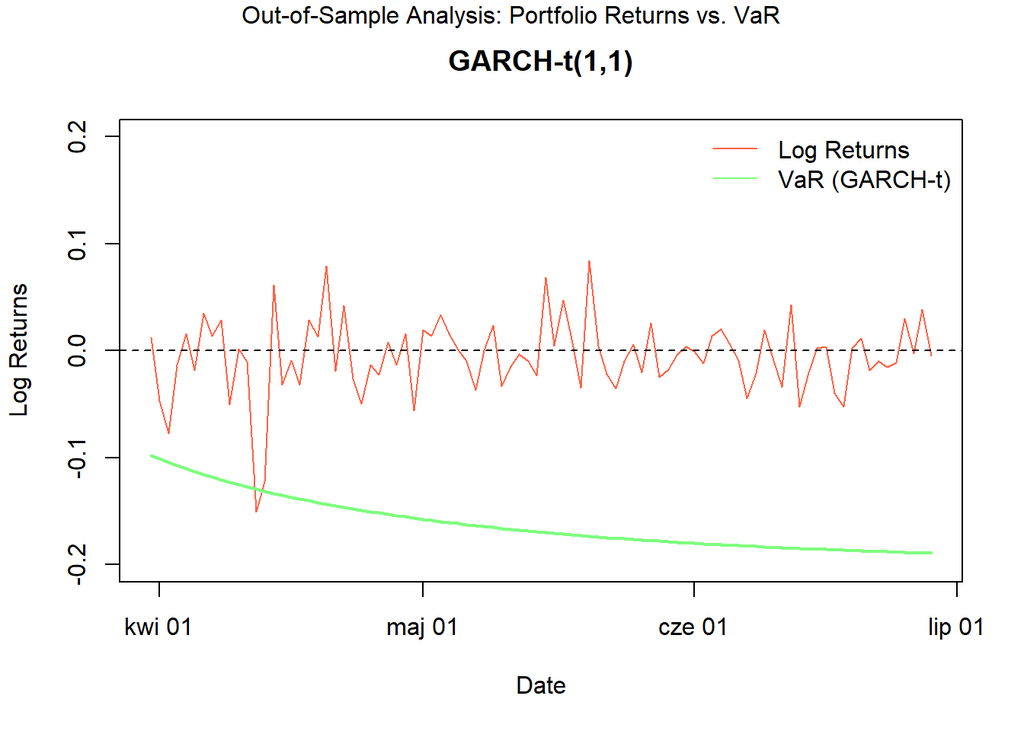

Percentages of observations exceeding VaR:

```
## Percentages of observations exceeding VaR for GARCH(1,1): 0.01111111
```

```
## Percentages of observations exceeding VaR for EGARCH(1,1): 0.02222222
```

```
## Percentages of observations exceeding VaR for GARCH-t(1,1): 0.01111111
```